# Credit EDA Case Study

### C. Segmented analysis

```python
#Creating the function segmented_table inorder to segment-wise visualize different columns
def segmented_table(df,val1,val2,r):
    plt.rcParams['figure.figsize']=(15, 6)
    plt.figure(figsize=(15,6))
    sns.set_style("white")
    col = pd.DataFrame(df.groupby([val1,val2])['TARGET'].value_counts()/df.groupby([val1,val2])['TARGET'].count())*100
    col.columns = ['Per_Target']
    target = pd.pivot_table(col, values ='Per_Target', index = [val1,val2],columns =['TARGET'], aggfunc = np.sum)
    target = target.reset_index()
    target.drop(0, axis = 1, inplace = True)
    val1_val2 = pd.pivot_table(target,values=1, index =[val2],columns =[val1], aggfunc = np.sum)
    plot = val1_val2.plot(kind='bar')
    plot.set_xlabel(f'{val2}', fontsize=16,fontweight= 10,color='Blue')
    plot.set_ylabel('Default(%)',fontsize=16,fontweight= 10,color='Blue')
    plot.set_title(f'Rate of Default by different {val1} and {val2}\n', fontsize=24,fontweight= 7,color='Black')
    plot.set_xticklabels(plot.get_xticklabels(), rotation = r, fontsize = 18, color="Black")
    plt.legend(bbox_to_anchor=(1.02, 1), loc='upper left', borderaxespad=0)
    plt.show()
```

- **Variable 1: 'INCOME' & 'AGE_GROUPS'**

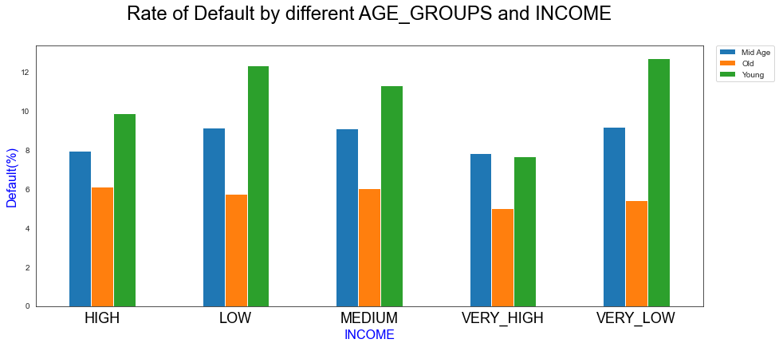

```python
#Plotting for INCOME and AGE_GROUPS
segmented_table(app_df,'AGE_GROUPS','INCOME',0)
```

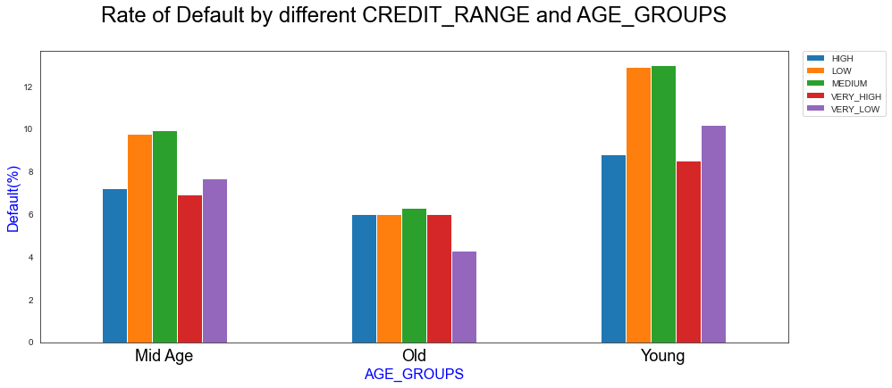

```python
#Plotting for CREDIT_RANGE and AGE_GROUPS
segmented_table(app_df,'CREDIT_RANGE','AGE_GROUPS',0)
```

**`Inferences:`**

- Age and Credit amount are inversely proportional.Chances of defaults are higher for low and medium credit amount.
- Young clients with low and medium credit amount are more likely to default.
- **Variable 3: 'NAME_EDUCATION_TYPE' & 'CODE_GENDER'**

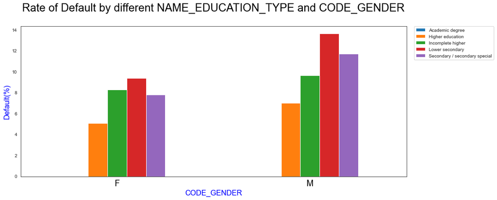

```python
#Plotting for NAME_EDUCATION_TYPE and CODE_GENDER
segmented_table(app_df,'NAME_EDUCATION_TYPE','CODE_GENDER',0)
```

**`Inferences:`**

- Male clients with lower secondary and Secondary education are more likely to default.
- **Variable 4: 'AGE_GROUPS' & 'CODE_GENDER'**

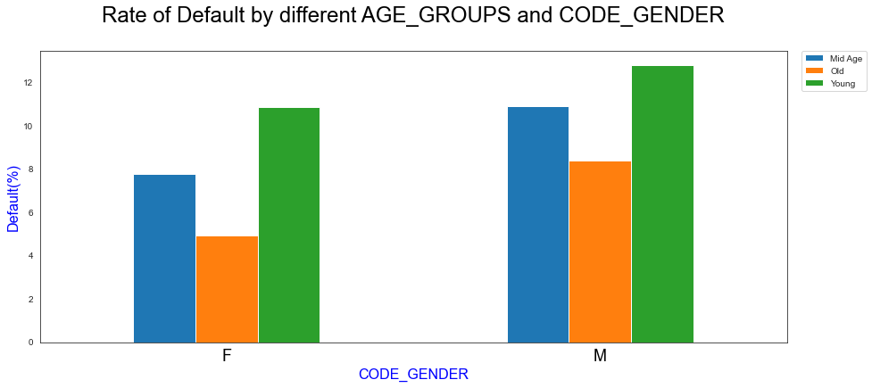

```python
#Plotting for AGE_GROUPS and CODE_GENDER
segmented_table(app_df,'AGE_GROUPS','CODE_GENDER',0)
```

**`Inferences:`**

- Young male clients are more likely to default.

### D. Bivariate & Multivariate analysis

```python
#Creating the function relation inorder to visualize correlation for selected columns
def relation(df):
    col = ['AMT_INCOME_TOTAL','AMT_CREDIT', 'AMT_ANNUITY', 'AMT_GOODS_PRICE', 'DAYS_BIRTH', 'DAYS_EMPLOYED','EXT_SOURCE_2']
    cor = df[col].corr()
    plot_default= sns.heatmap(cor,annot_kws={'fontsize': 18,'fontweight': 6,'color': 'Black'},cmap="Blues",annot=True,linewidth=0.5)

    plt.rcParams['figure.figsize']=(11, 7)
    plot_default.axes.set_title('\n CORRELATION MATRIX \n',fontsize= 18,fontweight= 9,color='Blue')
    plot_default.set_xticklabels(plot_default.get_xticklabels(), rotation = 90, fontsize = 16, color="Black")
    plot_default.set_yticklabels(plot_default.get_yticklabels(), rotation = 0, fontsize = 16, color="Black")
    plt.show()
```

- **Set 1: Correlation Matrix**

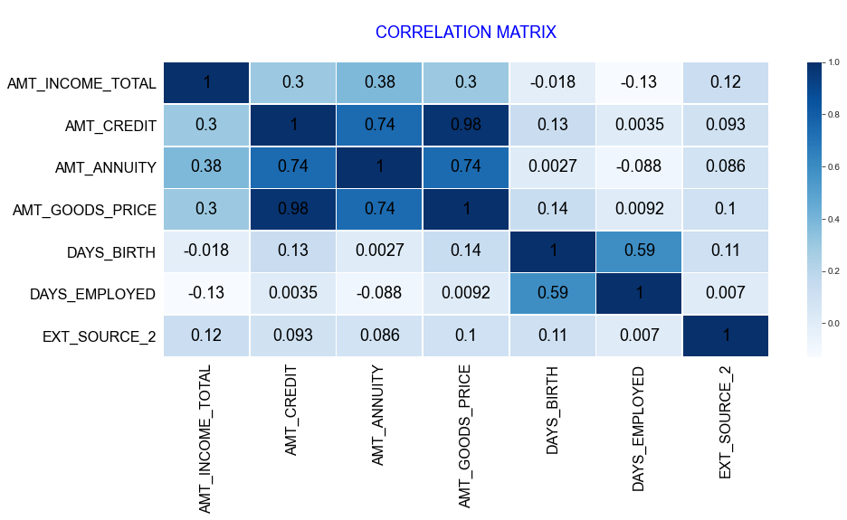

```python
#Plotting heatmap for target_default dataframe
relation(target_default)
```

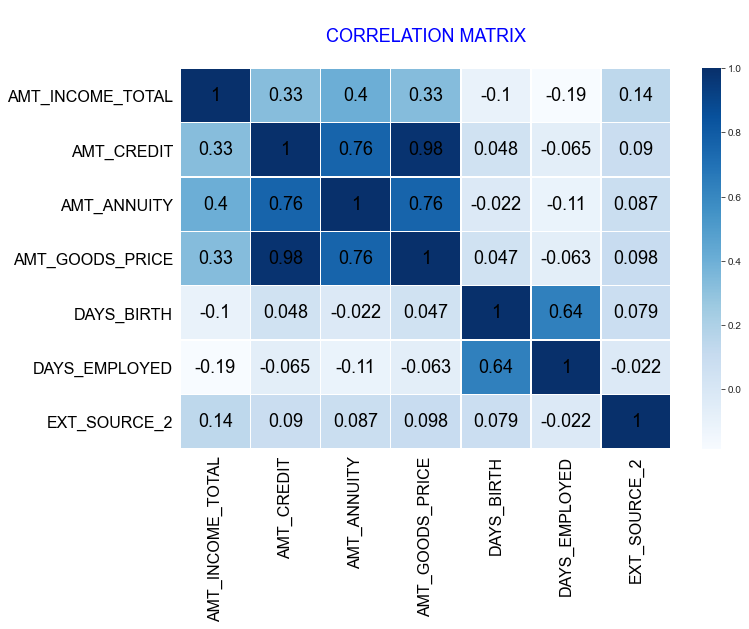

```python
#Plotting heatmap for target_nondefault dataframe
relation(target_nondefault)
```

**`Inferences:`**

- GOODS_PRICE and AMT_CREDIT, AMT_ANNUTY and AMT_AMT_CREDIT are variables that are having higher degree of correlation.
- **Set 2: Bivariate analysis using Box-plot**

```python
# Analyzing AMT_CREDIT with different columns to find the insights for factors driving loan amount credited

#Creating credit_check function to analyse and plot relation between AMT_CREDIT and selected columnns
category = ['NAME_CONTRACT_TYPE', 'CODE_GENDER', 'FLAG_OWN_CAR', 'FLAG_OWN_REALTY', 'NAME_INCOME_TYPE','NAME_EDUCATION_TYPE', 'NAME_FAMILY_STATUS', 'NAME_HOUSING_TYPE', 'INCOME',
            'AGE_GROUPS','CREDIT_RANGE']

def credit_check(df):
    plt.figure(figsize=(25,30))
    for ind, cat in enumerate(category):
        ax = plt.subplot(4,3,ind+1)
        sns.boxplot(x = cat, y = 'AMT_CREDIT', data=df)
        ax.set_xticklabels(ax.get_xticklabels(), rotation = 45, color="Black")
plt.show()
```

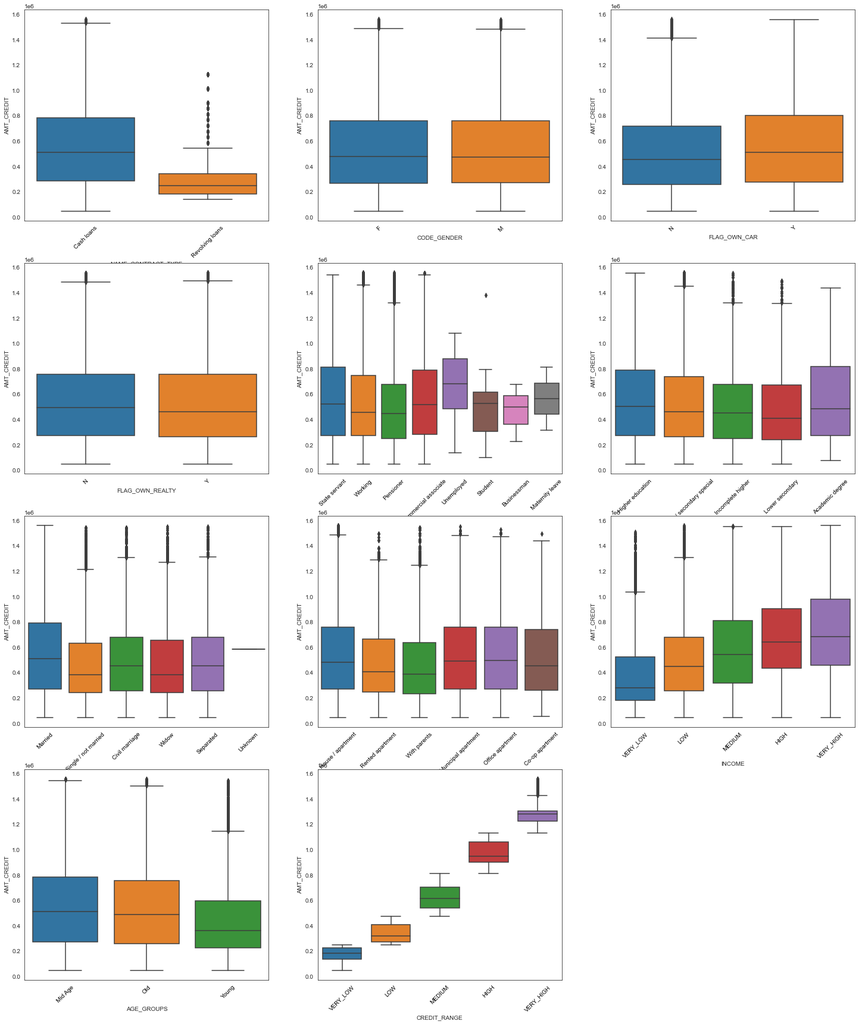

```python
#Plotting relation between AMT_CREDIT and selected columnns for target_nondefault Dataframe
credit_check(target_nondefault)
```

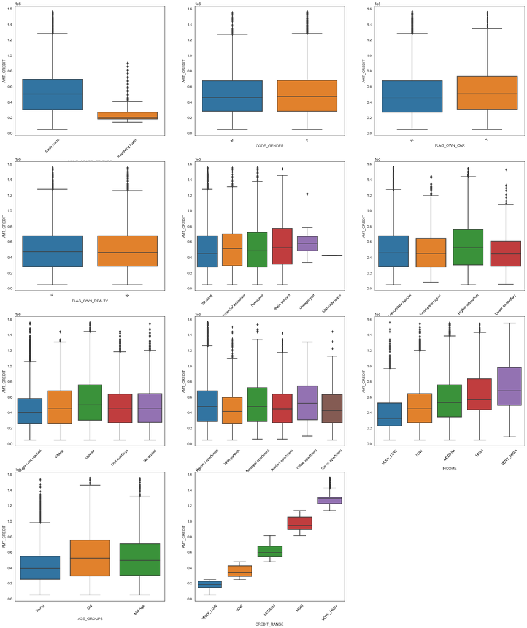

```python
#Plotting relation between AMT_CREDIT and selected columnns for target_default Dataframe
credit_check(target_default)
```

**`Inferences:`**

This box plots basically gives idea regarding the loan amount credited as we are analyzing AMT_Credit varible relation with other variables.

- Count for Cash Loans is higher than Revolving loans.
- Female category got more loan.
- Credited loan amount is higher for car owners
- State servents clients are getting higher amount of loan credited
- Client with Higher education are getting higher amount of loan credited
- Client with Married status are getting higher amount of loan credited
- Client who are living in municipal apartment, got more number of loans
- loan amount credited is directly proportional to income.High and Very High income category people are getting higher amount of loan credited

### A. Calcution of top 10 Correlation

```python
#Function for finding top 10 correlation
#code from - https://stackoverflow.com/questions/17778394/list-highest-correlation-pairs-from-a-large-correlation-matrix-in-pandas

def top_correlation (df,n):
    corr_matrix = df.corr()
    correlation = (corr_matrix.where(np.triu(np.ones(corr_matrix.shape), k=1).astype(np.bool))
                 .stack()
                 .sort_values(ascending=False))
    correlation = pd.DataFrame(correlation).reset_index()
    correlation.columns=["Variable_1","Variable_2","Correlation"]
    correlation = correlation.reindex(correlation.Correlation.abs().sort_values(ascending=False).index).reset_index().drop(["index"],axis=1)
    return correlation.head(n)
```

```python
#Displaying top10 Correlation for target_nondefault df
top_correlation(target_nondefault,10)
```

|  | Variable_1 | Variable_2 | Correlation |
| --- | --- | --- | --- |
| 0 | AMT_CREDIT | AMT_GOODS_PRICE | 0.981871 |
| 1 | REGION_RATING_CLIENT | REGION_RATING_CLIENT_W_CITY | 0.950916 |
| 2 | REG_REGION_NOT_WORK_REGION | LIVE_REGION_NOT_WORK_REGION | 0.861095 |
| 3 | REG_CITY_NOT_WORK_CITY | LIVE_CITY_NOT_WORK_CITY | 0.828870 |
| 4 | AMT_CREDIT | AMT_ANNUITY | 0.762966 |
| 5 | AMT_ANNUITY | AMT_GOODS_PRICE | 0.762624 |
| 6 | DAYS_BIRTH | DAYS_EMPLOYED | 0.638380 |
| 7 | REGION_POPULATION_RELATIVE | REGION_RATING_CLIENT | -0.497301 |
| 8 | REGION_POPULATION_RELATIVE | REGION_RATING_CLIENT_W_CITY | -0.497229 |
| 9 | REG_REGION_NOT_LIVE_REGION | REG_REGION_NOT_WORK_REGION | 0.453116 |

```python
#Displaying top10 Correlation for target_default df
top_correlation(target_default,10)
```

|  | Variable_1 | Variable_2 | Correlation |
| --- | --- | --- | --- |
| 0 | AMT_CREDIT | AMT_GOODS_PRICE | 0.977941 |
| 1 | REGION_RATING_CLIENT | REGION_RATING_CLIENT_W_CITY | 0.960149 |
| 2 | REG_REGION_NOT_WORK_REGION | LIVE_REGION_NOT_WORK_REGION | 0.850045 |
| 3 | REG_CITY_NOT_WORK_CITY | LIVE_CITY_NOT_WORK_CITY | 0.776857 |
| 4 | AMT_CREDIT | AMT_ANNUITY | 0.744166 |
| 5 | AMT_ANNUITY | AMT_GOODS_PRICE | 0.741647 |
| 6 | DAYS_BIRTH | DAYS_EMPLOYED | 0.591362 |
| 7 | REG_REGION_NOT_LIVE_REGION | REG_REGION_NOT_WORK_REGION | 0.495535 |
| 8 | REG_CITY_NOT_LIVE_CITY | REG_CITY_NOT_WORK_CITY | 0.473856 |
| 9 | REGION_POPULATION_RELATIVE | REGION_RATING_CLIENT_W_CITY | -0.423341 |

## Previous Application Data

### 1. Reading & Inspecting the Data

```python
#Reading previous_application.csv dataset using 'read_csv'
prev_df = pd.read_csv('previous_application.csv')
```

```python
#Checking previous_application in DataFrame
prev_df.head()
```

|  | SK_ID_PREV | SK_ID_CURR | NAME_CONTRACT_TYPE | AMT_ANNUITY | AMT_APPLICATION | AMT_CREDIT | AMT_DOWN_PAYMENT | AMT_GOODS_PRICE | WEEKDAY_APPR_PROCESS_START | HOUR_APPR_PROCESS_START | FLAG_LAST_APPL_PER_CONTRACT | NFLAG_LAST_APPL_IN_DAY | RATE_DOWN_PAYMENT | RATE_INTEREST_PRIMARY | RATE_INTEREST_PRIVILEGED | NAME_CASH_LOAN_PURPOSE | NAME_CONTRACT_STATUS | DAYS_DECISION | NAME_PAYMENT_TYPE | CODE_REJECT_REASON | NAME_TYPE_SUITE | NAME_CLIENT_TYPE | NAME_GOODS_CATEGORY | NAME_PORTFOLIO | NAME_PRODUCT_TYPE | CHANNEL_TYPE | SELLERPLACE_AREA | NAME_SELLER_INDUSTRY | CNT_PAYMENT | … |
| --- | --- | --- | --- | --- | --- | --- | --- | --- | --- | --- | --- | --- | --- | --- | --- | --- | --- | --- | --- | --- | --- | --- | --- | --- | --- | --- | --- | --- | --- | --- |
| 0 | 2030495 | 271877 | Consumer loans | 1730.430 | 17145.0 | 17145.0 | 0.0 | 17145.0 | SATURDAY | 15 | Y | 1 | 0.0 | 0.182832 | 0.867336 | XAP | Approved | -73 | Cash through the bank | XAP | NaN | Repeater | Mobile | POS | XNA | Country-wide | 35 | Connectivity | 12.0 | … |
| 1 | 2802425 | 108129 | Cash loans | 25188.615 | 607500.0 | 679671.0 | NaN | 607500.0 | THURSDAY | 11 | Y | 1 | NaN | NaN | NaN | XNA | Approved | -164 | XNA | XAP | Unaccompanied | Repeater | XNA | Cash | x-sell | Contact center | -1 | XNA | 36.0 | … |
| 2 | 2523466 | 122040 | Cash loans | 15060.735 | 112500.0 | 136444.5 | NaN | 112500.0 | TUESDAY | 11 | Y | 1 | NaN | NaN | NaN | XNA | Approved | -301 | Cash through the bank | XAP | Spouse, partner | Repeater | XNA | Cash | x-sell | Credit and cash offices | -1 | XNA | 12.0 | … |
| 3 | 2819243 | 176158 | Cash loans | 47041.335 | 450000.0 | 470790.0 | NaN | 450000.0 | MONDAY | 7 | Y | 1 | NaN | NaN | NaN | XNA | Approved | -512 | Cash through the bank | XAP | NaN | Repeater | XNA | Cash | x-sell | Credit and cash offices | -1 | XNA | 12.0 | … |
| 4 | 1784265 | 202054 | Cash loans | 31924.395 | 337500.0 | 404055.0 | NaN | 337500.0 | THURSDAY | 9 | Y | 1 | NaN | NaN | NaN | Repairs | Refused | -781 | Cash through the bank | HC | NaN | Repeater | XNA | Cash | walk-in | Credit and cash offices | -1 | XNA | 24.0 | … |

```python
#Print the Dimensions of previous_application df
print('Shape of the data:',prev_df.shape)
```

```
Shape of the data: (1670214, 37)
```

```python
#Checking Total No. of Rows-Columns and Total Null Values in DatFrame
print('########## Dataset Infomation ##########')
print ("Rows                 : " ,prev_df.shape[0])
print ("Columns              : " ,prev_df.shape[1])
print ("Total Missing values : ",prev_df.isnull().sum().values.sum())
```

```
########## Dataset Infomation ##########
Rows                 :  1670214
Columns              :  37
Total Missing values :  11109336
```

```python
#Verifying column-wise info of the dataframe
prev_df.info(verbose=True)
```

```
<class 'pandas.core.frame.DataFrame'>
RangeIndex: 1670214 entries, 0 to 1670213
Data columns (total 37 columns):
 #   Column                       Non-Null Count    Dtype
---  ------                       --------------    -----
 0   SK_ID_PREV                   1670214 non-null  int64
 1   SK_ID_CURR                   1670214 non-null  int64
 2   NAME_CONTRACT_TYPE           1670214 non-null  object
 3   AMT_ANNUITY                  1297979 non-null  float64
 4   AMT_APPLICATION              1670214 non-null  float64
 5   AMT_CREDIT                   1670213 non-null  float64
 6   AMT_DOWN_PAYMENT             774370 non-null   float64
 7   AMT_GOODS_PRICE              1284699 non-null  float64
 8   WEEKDAY_APPR_PROCESS_START   1670214 non-null  object
 9   HOUR_APPR_PROCESS_START      1670214 non-null  int64
```

[output cut: 29 more lines]

```python
#Checking the summary for the numeric columns
prev_df.describe()
```

|  | SK_ID_PREV | SK_ID_CURR | AMT_ANNUITY | AMT_APPLICATION | AMT_CREDIT | AMT_DOWN_PAYMENT | AMT_GOODS_PRICE | HOUR_APPR_PROCESS_START | NFLAG_LAST_APPL_IN_DAY | RATE_DOWN_PAYMENT | RATE_INTEREST_PRIMARY | RATE_INTEREST_PRIVILEGED | DAYS_DECISION | SELLERPLACE_AREA | CNT_PAYMENT | DAYS_FIRST_DRAWING | DAYS_FIRST_DUE | DAYS_LAST_DUE_1ST_VERSION | DAYS_LAST_DUE | DAYS_TERMINATION | NFLAG_INSURED_ON_APPROVAL |
| --- | --- | --- | --- | --- | --- | --- | --- | --- | --- | --- | --- | --- | --- | --- | --- | --- | --- | --- | --- | --- | --- |
| count | 1.670214e+06 | 1.670214e+06 | 1.297979e+06 | 1.670214e+06 | 1.670213e+06 | 7.743700e+05 | 1.284699e+06 | 1.670214e+06 | 1.670214e+06 | 774370.000000 | 5951.000000 | 5951.000000 | 1.670214e+06 | 1.670214e+06 | 1.297984e+06 | 997149.000000 | 997149.000000 | 997149.000000 | 997149.000000 | 997149.000000 | 997149.000000 |
| mean | 1.923089e+06 | 2.783572e+05 | 1.595512e+04 | 1.752339e+05 | 1.961140e+05 | 6.697402e+03 | 2.278473e+05 | 1.248418e+01 | 9.964675e-01 | 0.079637 | 0.188357 | 0.773503 | -8.806797e+02 | 3.139511e+02 | 1.605408e+01 | 342209.855039 | 13826.269337 | 33767.774054 | 76582.403064 | 81992.343838 | 0.332570 |
| std | 5.325980e+05 | 1.028148e+05 | 1.478214e+04 | 2.927798e+05 | 3.185746e+05 | 2.092150e+04 | 3.153966e+05 | 3.334028e+00 | 5.932963e-02 | 0.107823 | 0.087671 | 0.100879 | 7.790997e+02 | 7.127443e+03 | 1.456729e+01 | 88916.115834 | 72444.869708 | 106857.034789 | 149647.415123 | 153303.516729 | 0.471134 |
| min | 1.000001e+06 | 1.000010e+05 | 0.000000e+00 | 0.000000e+00 | 0.000000e+00 | -9.000000e-01 | 0.000000e+00 | 0.000000e+00 | 0.000000e+00 | -0.000015 | 0.034781 | 0.373150 | -2.922000e+03 | -1.000000e+00 | 0.000000e+00 | -2922.000000 | -2892.000000 | -2801.000000 | -2889.000000 | -2874.000000 | 0.000000 |
| 25% | 1.461857e+06 | 1.893290e+05 | 6.321780e+03 | 1.872000e+04 | 2.416050e+04 | 0.000000e+00 | 5.084100e+04 | 1.000000e+01 | 1.000000e+00 | 0.000000 | 0.160716 | 0.715645 | -1.300000e+03 | -1.000000e+00 | 6.000000e+00 | 365243.000000 | -1628.000000 | -1242.000000 | -1314.000000 | -1270.000000 | 0.000000 |
| 50% | 1.923110e+06 | 2.787145e+05 | 1.125000e+04 | 7.104600e+04 | 8.054100e+04 | 1.638000e+03 | 1.123200e+05 | 1.200000e+01 | 1.000000e+00 | 0.051605 | 0.189122 | 0.835095 | -5.810000e+02 | 3.000000e+00 | 1.200000e+01 | 365243.000000 | -831.000000 | -361.000000 | -537.000000 | -499.000000 | 0.000000 |
| 75% | 2.384280e+06 | 3.675140e+05 | 2.065842e+04 | 1.803600e+05 | 2.164185e+05 | 7.740000e+03 | 2.340000e+05 | 1.500000e+01 | 1.000000e+00 | 0.108909 | 0.193330 | 0.852537 | -2.800000e+02 | 8.200000e+01 | 2.400000e+01 | 365243.000000 | -411.000000 | 129.000000 | -74.000000 | -44.000000 | 1.000000 |
| max | 2.845382e+06 | 4.562550e+05 | 4.180581e+05 | 6.905160e+06 | 6.905160e+06 | 3.060045e+06 | 6.905160e+06 | 2.300000e+01 | 1.000000e+00 | 1.000000 | 1.000000 | 1.000000 | -1.000000e+00 | 4.000000e+06 | 8.400000e+01 | 365243.000000 | 365243.000000 | 365243.000000 | 365243.000000 | 365243.000000 | 1.000000 |

## PART A: DATA CLEANING

### Standardising & Fixing Invalid Values

```python
#Replacing'XNA' and 'XAP' values with NaN value.
prev_df.replace('XNA',np.nan,inplace=True)
prev_df.replace('XAP',np.nan,inplace=True)
```

### Handling the Missing value

```python
# calculating column-wise percentage of missing values and storing it in prev_null_df
prev_null_df = round(100*(prev_df.isnull().sum() / len(prev_df.index)), 2)
prev_null_df.head()
```

```
SK_ID_PREV             0.00
SK_ID_CURR             0.00
NAME_CONTRACT_TYPE     0.02
AMT_ANNUITY           22.29
AMT_APPLICATION        0.00
dtype: float64
```

```python
#Counting No. of Columns having more than 50% null value
print("Columns having 50% null value: ", prev_null_df[prev_null_df>50].size)
```

```
Columns having 50% null value:  9
```

```python
#Dropping columns having null values more than 50% from app_data dataframe
prev_df.drop(columns = prev_null_df[prev_null_df>50].index, axis = 1,inplace=True)
print('Size of the dataset after removing the missing values',prev_df.shape)
```

```
Size of the dataset after removing the missing values (1670214, 28)
```

```python
#checking missing values in each column and sorting columns in Descending order
round(100*(prev_df.isnull().sum() / len(prev_df.index)), 2).sort_values(ascending=False).head()
```

```
NAME_TYPE_SUITE              49.12
DAYS_FIRST_DRAWING           40.30
DAYS_TERMINATION             40.30
DAYS_LAST_DUE                40.30
DAYS_LAST_DUE_1ST_VERSION    40.30
dtype: float64
```

```python
# #Identiying the columns that are not useful for our case study anylsis and dropping them manually

drop_col = ['WEEKDAY_APPR_PROCESS_START', 'HOUR_APPR_PROCESS_START','FLAG_LAST_APPL_PER_CONTRACT',
                      'NFLAG_LAST_APPL_IN_DAY','SELLERPLACE_AREA','PRODUCT_COMBINATION']

#Displaying No. of columns that needs to be dropped
len(drop_col)
```

```
6
```

```python
#Dropping Unwanted olumns from data
prev_df.drop(columns=drop_col,axis=1,inplace=True)
print('Size of the dataset after removing the missing values',prev_df.shape)
```

```
Size of the dataset after removing the missing values (1670214, 22)
```

### Handling Outliers

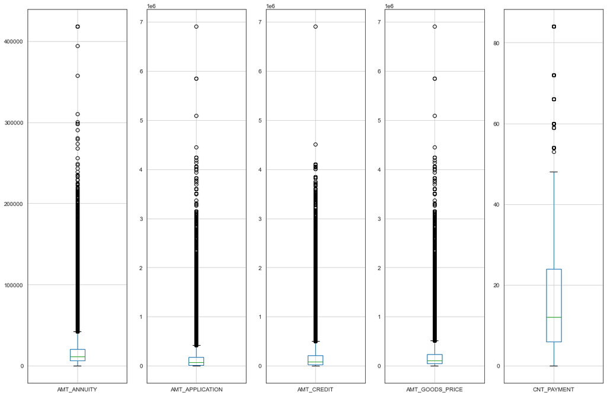

```python
#Plotting Box-plot inorder to detect outlier presence for selected columns

check_outliers = ['AMT_ANNUITY','AMT_APPLICATION','AMT_CREDIT','AMT_GOODS_PRICE','CNT_PAYMENT']
plt.figure(figsize=(18,12))
for j, check in enumerate(check_outliers):
    plt.subplot(1,5, j+1)
    prev_df.boxplot(column = check)
plt.show()
```

```python
#Dealing with outliers using 1.5 IQR method for selected column
for check in check_outliers:
    q1 = prev_df[check].quantile(0.25)
    q3 = prev_df[check].quantile(0.75)
    iqr = q3-q1
    range_low  = q1-1.5*iqr
    range_high = q3+1.5*iqr
    prev_df = prev_df.loc[(prev_df[check] > range_low) & (prev_df[check] < range_high)]
```

## PART B: Exploratory Data Analysis

### 1. Univariate Analysis

```python
#Creating the function Categorical_prevdata_plot inorder to visualize the different Categorical columns

def Categorical_prevdata_plot(val,r):#Val is column name & r is the rotation angle for x ticks
    sns.set_style("whitegrid")
    f,ax1 =plt.subplots(1,1,figsize=(15, 7))
    plot=sns.countplot(x = val, data = prev_df,ax=ax1)
    plot.set_title(f"\nDistribution of {val}\n", fontsize=24,fontweight= 7,color='Black')
    plot.set_xlabel(f"\n{val} \n\n", fontsize=16,fontweight= 10,color='Blue')
    plot.set_ylabel("\nTotal Counts\n", fontsize=16,fontweight= 10,color='Blue')
    plot.set_xticklabels(plot.get_xticklabels(), rotation = r, fontsize = 18, color="Black")
#     plt.legend(fontsize=10, title_fontsize=15,bbox_to_anchor=(1.02, 1), loc='upper left', borderaxespad=0)
    plt.show()
```

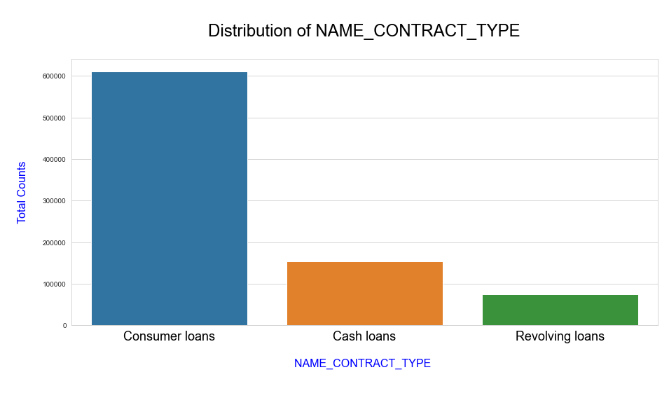

```python
#Plotting NAME_CONTRACT_TYPE column using Categorical_prevdata_plot function
Categorical_prevdata_plot('NAME_CONTRACT_TYPE',0)
```

**`Inferences:`**

- Count for Consumer Loan type category is higher incomparison to Cash loans and Revolving loans

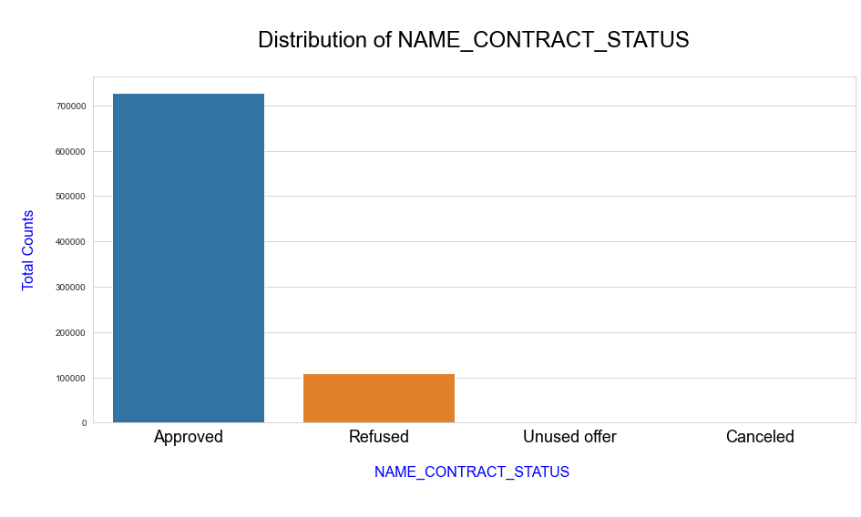

```python
#Plotting NAME_CLIENT_TYPE column using Categorical_prevdata_plot function
Categorical_prevdata_plot('NAME_CONTRACT_STATUS',0)
```

**`Inferences:`**

- Count of Approved status is very much high when compared to other types like rejected or canceled.

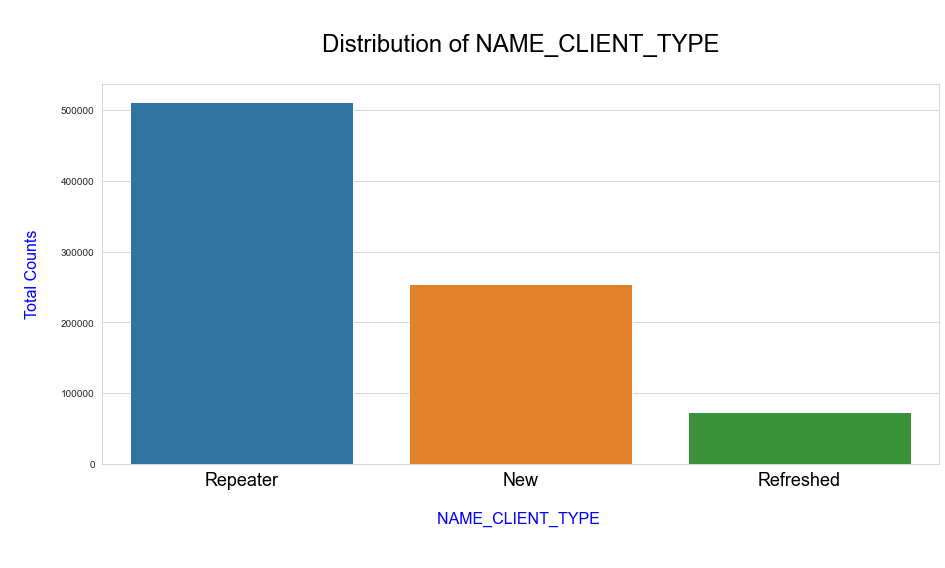

```python
#Plotting NAME_CLIENT_TYPE column using Categorical_prevdata_plot function
Categorical_prevdata_plot('NAME_CLIENT_TYPE',0)
```

**`Inferences:`**

- Number of Repeater clients is higher when compared to new clients.

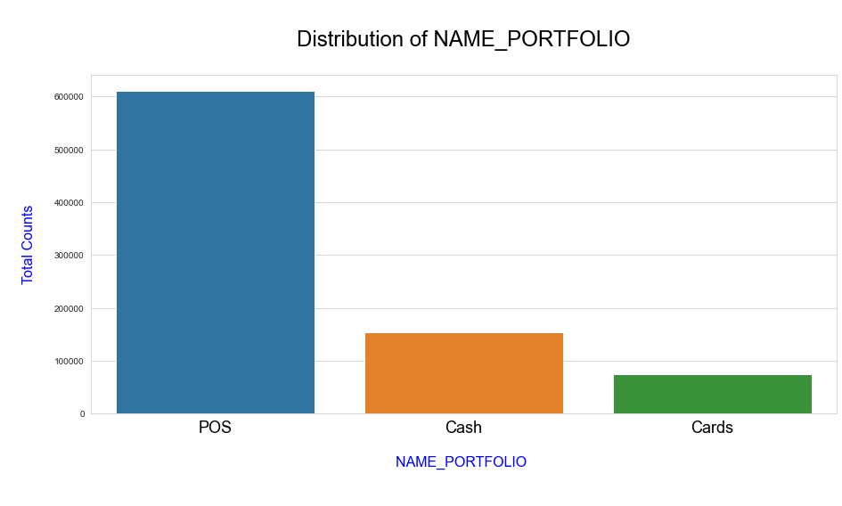

```python
#Plotting NAME_PORTFOLIO column using Categorical_prevdata_plot function
Categorical_prevdata_plot('NAME_PORTFOLIO',0)
```

**`Inferences:`**

- Count of POS type loans is higher.

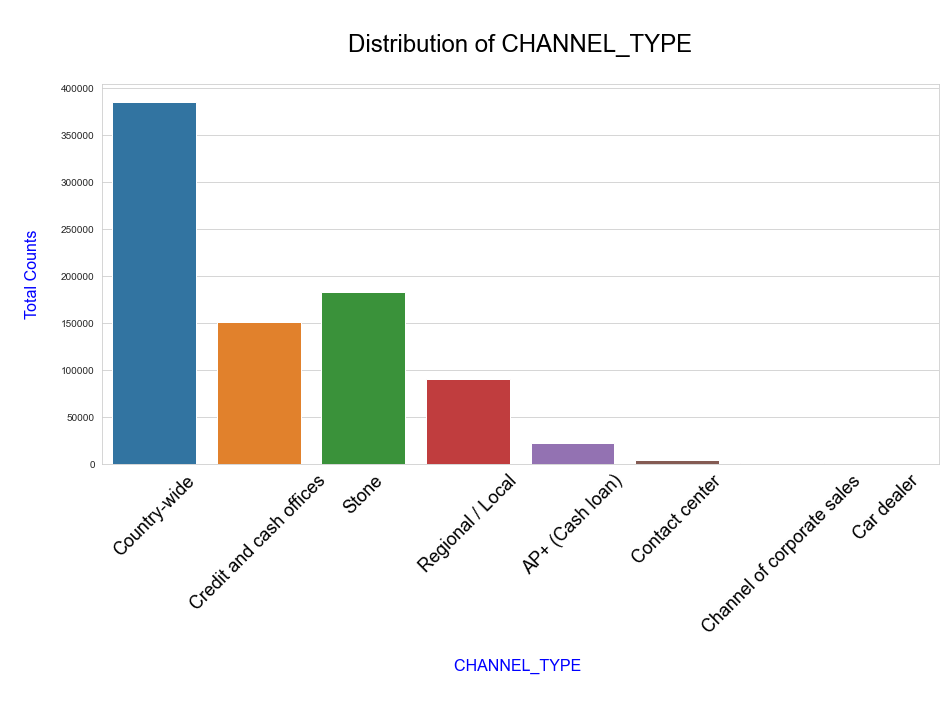

```python
#Plotting CHANNEL_TYPE column using Categorical_prevdata_plot function
Categorical_prevdata_plot('CHANNEL_TYPE',45)
```

**`Inferences:`**

- Country-wide channel is most popular channel type.

```python
#Creating the function Continous_prevdata_plot inorder to visualize the different Continous columns
def Continous_prevdata_plot(val):
    sns.set_style("whitegrid")
    plt.figure(figsize=(8,5))
    sns.distplot(prev_df[val], hist =False,label = f'{val}')
    plt.legend()
    plt.title(f'{val}')
    plt.show()
```

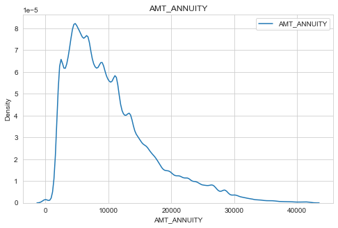

```python
#Plotting AMT_ANNUITY column using Continous_prevdata_plot function
Continous_prevdata_plot('AMT_ANNUITY')
```

**`Inferences:`**

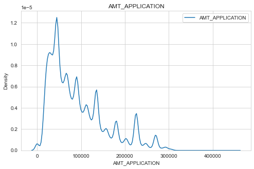

```python
#Plotting AMT_APPLICATION column using Continous_prevdata_plot function
Continous_prevdata_plot('AMT_APPLICATION')
```

**`Inferences:`**

- Most of the loan application amount were below 300000.
- As analysed from graph, there is a spike around 50000.

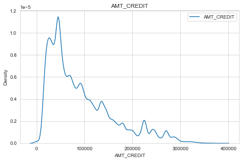

```python
#Plotting AMT_CREDIT column using Continous_prevdata_plot function
Continous_prevdata_plot('AMT_CREDIT')
```

**`Inferences:`**

- The graph pattern is similar to AMT_APPLICATION.

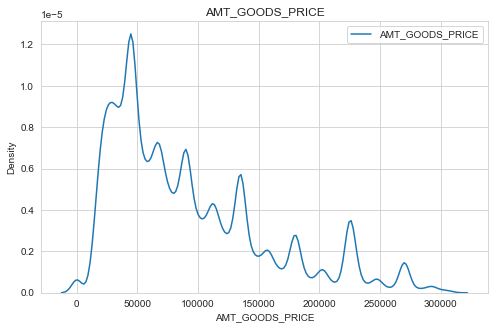

```python
#Plotting AMT_GOODS_PRICE column using Continous_prevdata_plot function
Continous_prevdata_plot('AMT_GOODS_PRICE')
```

**`Inferences:`**

- The graph pattern is similar to AMT_APPLICATION.

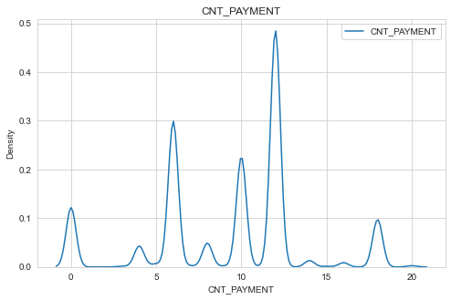

```python
#Plotting CNT_PAYMENT column using Continous_prevdata_plot function
Continous_prevdata_plot('CNT_PAYMENT')
```

**`Inferences:`**

- Most of the loan application were having term of previous credit either 6 years or 10 years or 12 to 13 years.
- Out of these also 12 to 13 years term is most popular one.

### Bivariate & Multivariate analysis

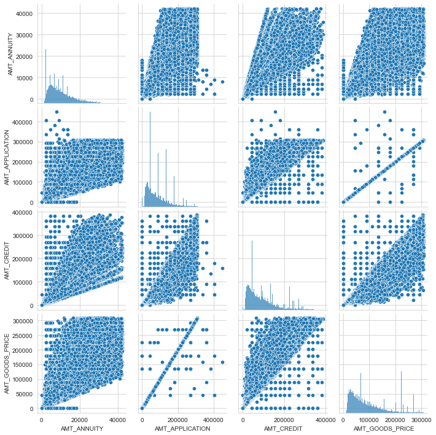

```python
#Pairplot for prev_df dataframe
pairplot_prevdata = prev_df[['AMT_ANNUITY', 'AMT_APPLICATION', 'AMT_CREDIT', 'AMT_GOODS_PRICE']]
sns.pairplot(pairplot_prevdata)
plt.show()
```

**`Inferences:`**

- AMT_APPLICATION is highly correlated with columns such as AMT_ANNUTY, AMT_AMT_CREDIT, AMT_GOODS_PRICE

### Calcution of top 10 Correlation

```python
#Displaying top10 Correlation for prev_df dataframe
top_correlation(prev_df,10)
```

|  | Variable_1 | Variable_2 | Correlation |
| --- | --- | --- | --- |
| 0 | AMT_APPLICATION | AMT_GOODS_PRICE | 0.999749 |
| 1 | AMT_CREDIT | AMT_GOODS_PRICE | 0.964994 |
| 2 | AMT_APPLICATION | AMT_CREDIT | 0.964796 |
| 3 | DAYS_LAST_DUE | DAYS_TERMINATION | 0.957745 |
| 4 | AMT_ANNUITY | AMT_CREDIT | 0.800442 |
| 5 | AMT_ANNUITY | AMT_GOODS_PRICE | 0.799634 |
| 6 | AMT_ANNUITY | AMT_APPLICATION | 0.799423 |
| 7 | DAYS_FIRST_DRAWING | DAYS_LAST_DUE_1ST_VERSION | -0.743224 |
| 8 | DAYS_FIRST_DUE | DAYS_LAST_DUE_1ST_VERSION | 0.582153 |
| 9 | CNT_PAYMENT | DAYS_LAST_DUE_1ST_VERSION | -0.572667 |

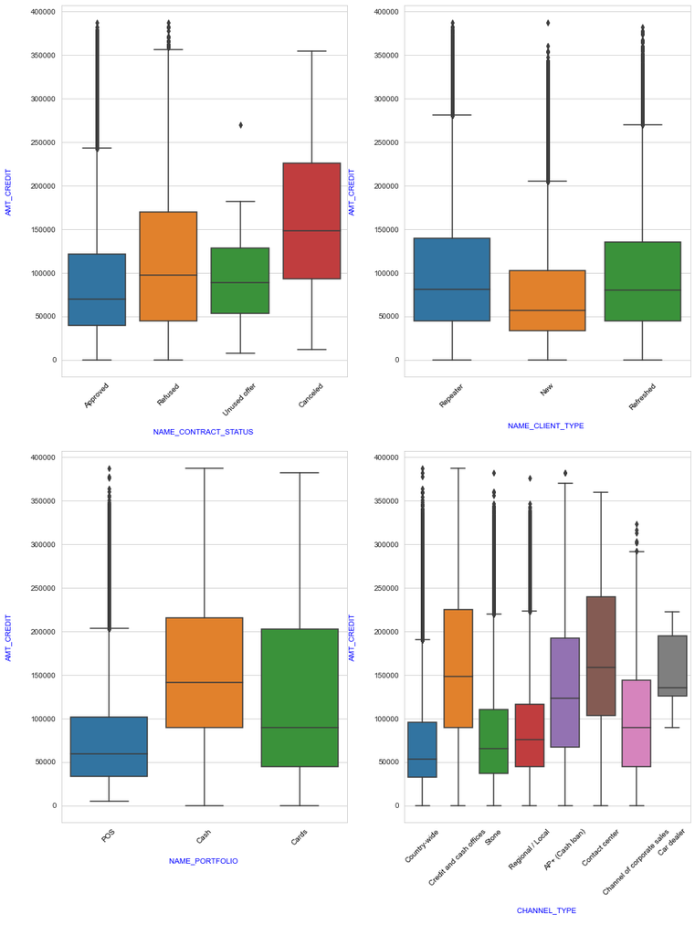

```python
# Analyzing AMT_CREDIT with different columns to find the insights for factors driving loan amount credited

prevdf_category = ['NAME_CONTRACT_STATUS', 'NAME_CLIENT_TYPE', 'NAME_PORTFOLIO', 'CHANNEL_TYPE']

plt.figure(figsize=(15,20))
for ind, cat in enumerate(prevdf_category):
    ax = plt.subplot(2,2,ind+1)
    sns.boxplot(x = cat, y = 'AMT_CREDIT', data=prev_df)
    ax.set_xticklabels(ax.get_xticklabels(), rotation = 45, fontsize = 10, color="Black")
    ax.set_xlabel(f"\n{cat} \n\n", fontsize=10,fontweight= 10,color='Blue')
    ax.set_ylabel(f"AMT_CREDIT \n\n", fontsize=10,fontweight= 10,color='Blue')
plt.show()
```

**`Inferences:`**

This box plots basically gives idea regarding the loan amount credited as we are analyzing AMT_Credit varible relation with other variables.

### Segmented analysis

```python
## Merging the two datframes to do perform analysis
col = ['SK_ID_CURR','TARGET','CODE_GENDER','NAME_EDUCATION_TYPE','NAME_FAMILY_STATUS','INCOME','AGE_GROUPS','CREDIT_RANGE', 'DAYS_BIRTH']
app_columns = app_df[col]
comb_df = pd.merge(app_columns, prev_df, how='left', on='SK_ID_CURR')
```

```python
#Veriying newly created Comb_df
comb_df.head()
```

|  | SK_ID_CURR | TARGET | CODE_GENDER | NAME_EDUCATION_TYPE | NAME_FAMILY_STATUS | INCOME | AGE_GROUPS | CREDIT_RANGE | DAYS_BIRTH | SK_ID_PREV | NAME_CONTRACT_TYPE | AMT_ANNUITY | AMT_APPLICATION | AMT_CREDIT | AMT_GOODS_PRICE | NAME_CONTRACT_STATUS | DAYS_DECISION | NAME_PAYMENT_TYPE | NAME_TYPE_SUITE | NAME_CLIENT_TYPE | NAME_PORTFOLIO | CHANNEL_TYPE | CNT_PAYMENT | NAME_YIELD_GROUP | DAYS_FIRST_DRAWING | DAYS_FIRST_DUE | DAYS_LAST_DUE_1ST_VERSION | DAYS_LAST_DUE | DAYS_TERMINATION | … |
| --- | --- | --- | --- | --- | --- | --- | --- | --- | --- | --- | --- | --- | --- | --- | --- | --- | --- | --- | --- | --- | --- | --- | --- | --- | --- | --- | --- | --- | --- | --- |
| 0 | 100002 | 1 | M | Secondary / secondary special | Single / not married | MEDIUM | Young | LOW | 25 | NaN | NaN | NaN | NaN | NaN | NaN | NaN | NaN | NaN | NaN | NaN | NaN | NaN | NaN | NaN | NaN | NaN | NaN | NaN | NaN | … |
| 1 | 100003 | 0 | F | Higher education | Married | HIGH | Mid Age | VERY_HIGH | 45 | 2396755.0 | Consumer loans | 6737.31 | 68809.50 | 68053.5 | 68809.50 | Approved | -2341.0 | Cash through the bank | Family | Refreshed | POS | Country-wide | 12.0 | middle | 365243.0 | -2310.0 | -1980.0 | -1980.0 | -1976.0 | … |
| 2 | 100004 | 0 | M | Secondary / secondary special | Single / not married | VERY_LOW | Old | VERY_LOW | 52 | 1564014.0 | Consumer loans | 5357.25 | 24282.00 | 20106.0 | 24282.00 | Approved | -815.0 | Cash through the bank | Unaccompanied | New | POS | Regional / Local | 4.0 | middle | 365243.0 | -784.0 | -694.0 | -724.0 | -714.0 | … |
| 3 | 100006 | 0 | F | Secondary / secondary special | Civil marriage | LOW | Old | LOW | 52 | 1489396.0 | Revolving loans | 13500.00 | 270000.00 | 270000.0 | 270000.00 | Approved | -181.0 | NaN | Unaccompanied | Repeater | Cards | Credit and cash offices | 0.0 | NaN | 365243.0 | 365243.0 | 365243.0 | 365243.0 | 365243.0 | … |
| 4 | 100006 | 0 | F | Secondary / secondary special | Civil marriage | LOW | Old | LOW | 52 | 2299329.0 | Consumer loans | 2482.92 | 26912.34 | 24219.0 | 26912.34 | Approved | -617.0 | NaN | NaN | New | POS | Stone | 12.0 | middle | 365243.0 | -545.0 | -215.0 | -425.0 | -416.0 | … |

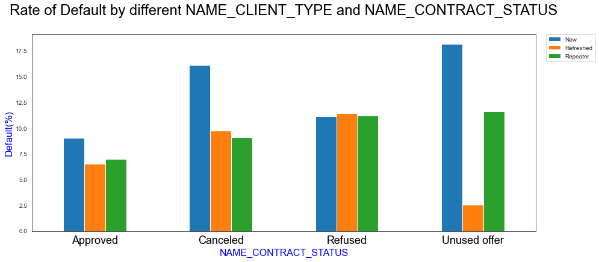

```python
#Plotting for NAME_CLIENT_TYPE and NAME_CONTRACT_STATUS
segmented_table(comb_df,'NAME_CLIENT_TYPE','NAME_CONTRACT_STATUS',0)
```

**`Inferences:`**

- New clients are more likely to default in comparision to repeater clients.

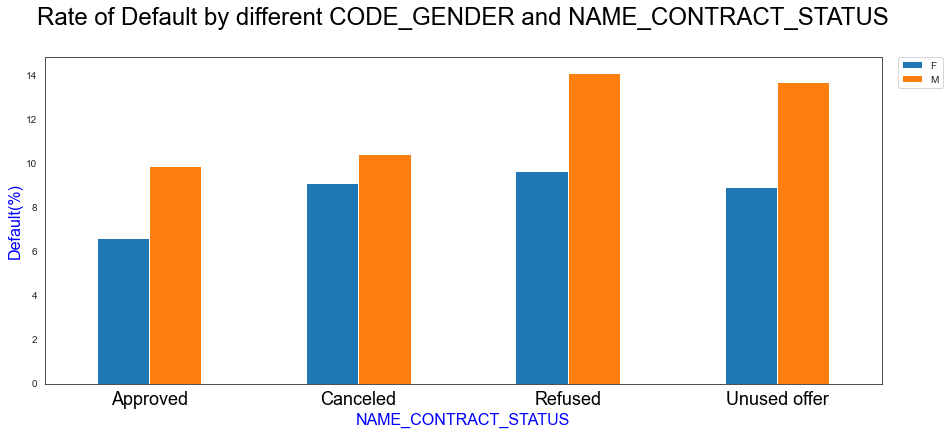

```python
#Plotting for CODE_GENDER and NAME_CONTRACT_STATUS
segmented_table(comb_df,'CODE_GENDER','NAME_CONTRACT_STATUS',0)
```

**`Inferences:`**

- Male category is having higher ratio of default when compared to female category.
- Male clients with previous application as refused are having even higher chances of defaults.

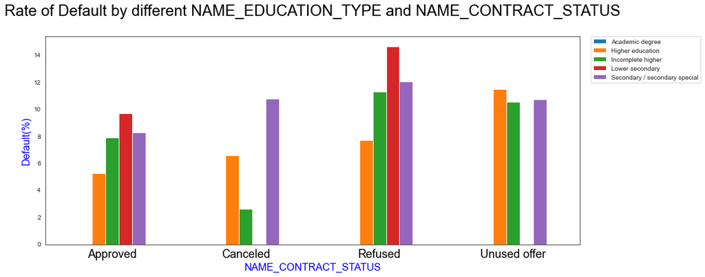

```python
#Plotting for NAME_EDUCATION_TYPE and NAME_CONTRACT_STATUS
segmented_table(comb_df,'NAME_EDUCATION_TYPE','NAME_CONTRACT_STATUS',0)
```

**`Inferences:`**

- Highest number of defaults in current loan are made by clients who have lower secondary education with refused previous loan

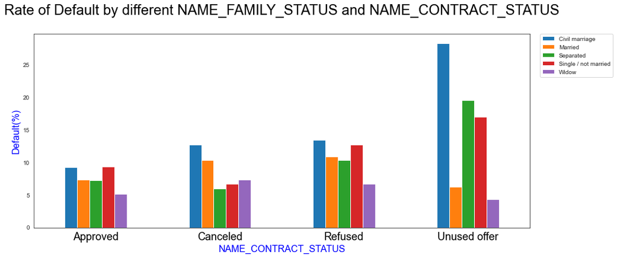

```python
#Plotting for NAME_FAMILY_STATUS and NAME_CONTRACT_STATUS
segmented_table(comb_df,'NAME_FAMILY_STATUS','NAME_CONTRACT_STATUS',0)
```

**`Inferences:`**

- Higher chances of default in current loan are made by clients who have Civil marriage with unused previous loan offer

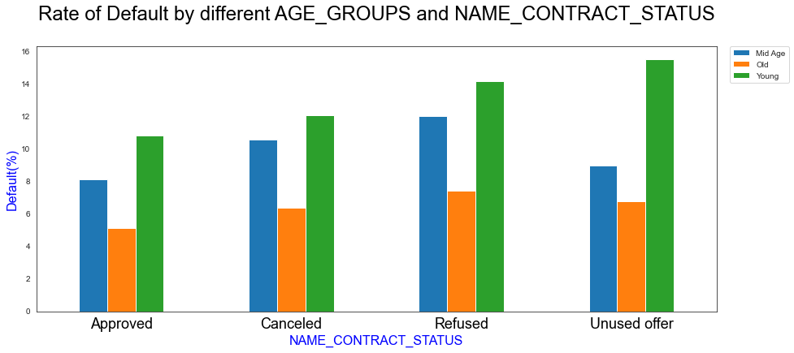

```python
#Plotting for AGE_GROUPS and NAME_CONTRACT_STATUS
segmented_table(comb_df,'AGE_GROUPS','NAME_CONTRACT_STATUS',0)
```

**`Inferences:`**

- Highest number of defaults in current loan are made by clients who are young with unused previous loan offer.

## Conculsion

**Safe Clients** - These are the category or group that bank can target or approve loan for them as these groups are having minimal Default risk.

• Old Age Group Clients.  
• State servant Clients.  
• High income category Clients.  
• Female clients in old age Group.  
• Client having higher education.  
• Clients with previous loan status as approved.  
• Widow Category clients can be targeted.

**Risky Clients** - These are the category or group that bank can avoid to approve loans as these clients have higher chances of Default associated with them.

- Client having Lower secondary education.
- Male clients with civil marriage.
- Clients with previous loan status as cancelled or refused.